# A Network Epidemic Model for Online Community Commissioning Data

2017-03-24

https://digitalcivics.io

A computing research lab in

- Human-computer interaction
- Social and ubiquitous computing

Themes:

- Health and social care
- Education
- Politics

## [Learning Circle](https://learningcircle.io)

Online learning platform

Different from Massive Open Online Course (MOOC)

- passive learning

Students learn from interaction with each other and mentors/experts

- active learning
- the line between student and teacher becomes less clear

## [Connecting Classes](https://jonathanworth.org/connecting_classes/)

- Just like an ordinary class, but students take notes via twitter or write blogs
- [#CClasses](https://twitter.com/search?q=%23CClasses) and the class specific hashtags for extracting and collecting data
- Can interact in the social network with each other, as well as *people outside the classroom*, e.g. experts in the subject
- Expand the learning space beyond the physical classroom

## Social network analysis

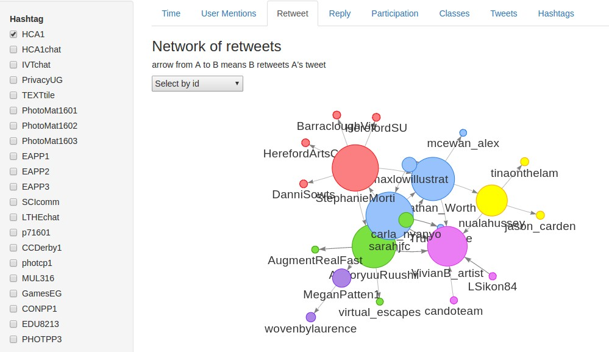

## Social network analysis

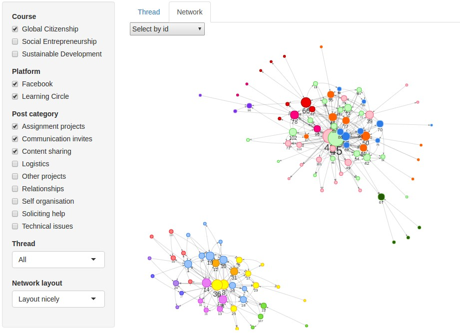

## [Feed Finder](http://feed-finder.co.uk)

- An app for finding breastfeeding friendly places
- User review system
- How about other ideas that can be turned into a geolocation-based app?
- What if we let the community decide what app to develop?

## [App Movement](https://app-movement.com)

Support/sharing stage

- Start a movement, and share to friends on social network
- Potential users support and share

Design stage

- Use the templates provided by the developers
- Vote on the design aspects of the app

Launch stage

- Similar to Feed Finder, users search for places and give reviews

## App Movement

Not all movements reach the target support and get launched

Some successful apps

- [Drone Zones](https://app-movement.com/apps/64)
- [Gender Neutral Toilet Finder](https://app-movement.com/apps/77)
- [Feed Finder, Lebanese version](https://app-movement.com/apps/83)

The sharing of a movement is like spreading an "epidemic" on the social network

This motivates us to develop a network epidemic model for the sharing data

## Epidemic models

Susceptible-Infected-Recovered (SIR) model

[figure not shown]

[image source](https://upload.wikimedia.org/wikipedia/commons/3/32/Sirsys-p9.png)

## Epidemic models

Compartment models

- Each individual is at exactly one stage at any time
- Potentially goes from one stage to another

Classical assumptions governing the dynamics

- Markovian
- Homogeneous mixing

See e.g. Andersson and Britton (2000) [(link)](http://staff.math.su.se/tom.britton/newmain.pdf)

## Epidemic models

**Modelling heterogeneity**

Multiple levels of mixing

- Ball, Mollison, and Scalia-Tomba (1997): [two levels](http://projecteuclid.org/download/pdf_1/euclid.aoap/1034625252)
- Britton, Kypraios, and O’Neill (2011): [three levels](http://onlinelibrary.wiley.com/doi/10.1111/j.1467-9469.2010.00726.x/full)

Not quite applicable to our data

- No information on such levels in the social network

## Epidemic models

**Network modelling**

Previous work

- Britton and O’Neill (2002) [(link)](http://onlinelibrary.wiley.com/doi/10.1111/1467-9469.00296/abstract)
- Neal and Roberts (2005) [(link)](http://link.springer.com/article/10.1007/s11222-005-4074-7)
- Focus on inference algorithms

Based on Bernoulli random graph (BRG)

- \(\Pr\)(any two individuals are connected) = \(p\)
- Such probability independent of all other connections
- Not quite realistic for social networks

## Network models

Barabási and Albert (1999): [Preferential attachment (PA) model](http://barabasi.com/f/67.pdf)

- Nodes join network sequentially, each with \(\mu\) new edges
- Each existing node gets an edge with probability proportional to current degree

[figure not shown]

[image source](http://www3.nd.edu/~networks/Linked/fig7_1.jpg)

## Network models

Power-law degree distribution

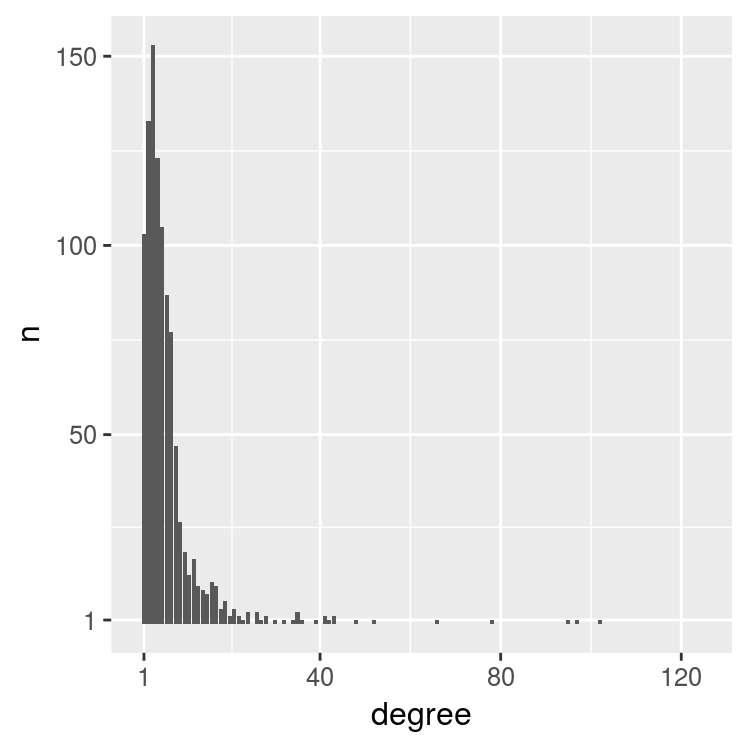

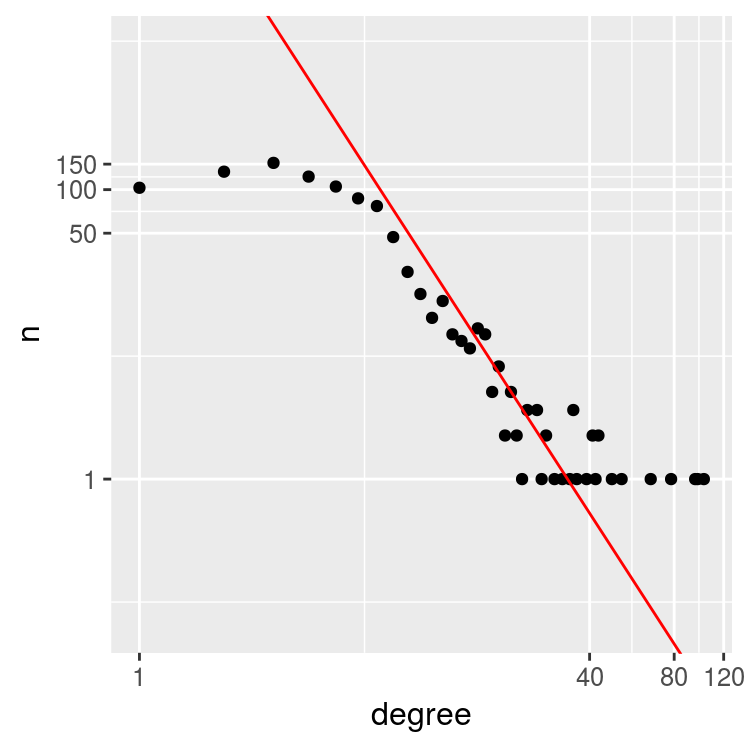

## Network models

Small path lengths

- Six degrees of separation

High clustering

- Three typical nodes \(A,B\) and \(C\)
- Assume \(A\leftrightarrow B\) and \(B\leftrightarrow C\)
- Clustering coefficient: how likely that \(A\leftrightarrow C\)
- BRG: whether each pair is connected is independent of other pairs a priori

## Network models

**Epidemic modelling**

Compartment models represented by ordinary differential equations

- \(\displaystyle\frac{dS}{dt}=-\beta IS, \quad\qquad\frac{dI}{dt}=\beta IS-\gamma I, \quad\qquad\frac{dR}{dt}=\gamma I\)

Incorporate network aspects as covariate

- E.g. same parameter values for nodes with same degree
- [Comprehensive review](http://journals.aps.org/rmp/abstract/10.1103/RevModPhys.87.925) by Pastor-Satorras et al. (2015)

Quite remote from previously introduced statistical models

## Ingredients

Population: \(m\) nodes/individuals

The epidemic times \(\boldsymbol{I}=(I_1,I_2,\ldots,I_m)\)

- Susceptible-Infected (SI) model
- Markovian, constant infection rate \(\beta\)

The underlying graph/network \(\boldsymbol{G}=\{G_{ij}\}_{m\times m}\)

- PA model, parameter \(\mu\)
- \(G_{ij}=1\) if \(i\leftrightarrow j\) for \(i\neq j\), \(0\) otherwise

The transmission tree \(\boldsymbol{P}=\{P_{ij}\}_{m\times m}\)

- \(P_{ij}=1\) if node \(j\) is infected by \(i\), \(0\) otherwise

## Model

**Step 1: Obtain new edges for the nodes**

Index the nodes by their order of entering the network

One edge to start with: nodes \(1\leftrightarrow2\)

Node \(i~(>2)\) brings in \(x_i\) new edges

- \(x_i=\mu\) (constant) in original PA model too restrictive
- \(x_i=y_i \wedge (i-1)\) where \(y_i\sim\) Poission \((\mu)\)

## Model

**Step 1: Obtain new edges for the nodes**

Toy example: \(m=8,\mu=3\)

- \(x_3=2,~x_4=3,~x_5=4,~x_6=2,~x_7=3,~x_8=4\)

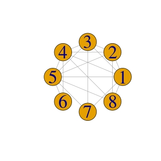

```
## [1] "G"
##
## [1,] . 1 1 1 1 . 1 1
## [2,] 1 . 1 1 1 . . 1
## [3,] 1 1 . 1 1 . 1 .
## [4,] 1 1 1 . 1 1 . 1
## [5,] 1 1 1 1 . 1 1 1
## [6,] . . . 1 1 . . .
## [7,] 1 . 1 . 1 . . .
## [8,] 1 1 . 1 1 . . .
```

## Model

**Step 1: Obtain new edges for the nodes**

Toy example: \(m=8,\mu=3\)

- \(x_3=2,~x_4=3,~x_5=4,~x_6=2,~x_7=3,~x_8=4\)

Relationship between \(x_i\) and \(G_{ij}\)

- For \(i>2\), \(x_i=\sum_{j=1}^{i-1}G_{ij}\)
- \(x_i\) essentially the column sum of \(G_{ij}\), up to the major diagonal

```
## [1] "G"
##
## [1,] . 1 1 1 1 . 1 1
## [2,] 1 . 1 1 1 . . 1
## [3,] 1 1 . 1 1 . 1 .
## [4,] 1 1 1 . 1 1 . 1
## [5,] 1 1 1 1 . 1 1 1
## [6,] . . . 1 1 . . .
## [7,] 1 . 1 . 1 . . .
## [8,] 1 1 . 1 1 . . .
```

## Model

**Step 1: Obtain new edges for the nodes**

Likelihood: \[ L_1(\boldsymbol{G};\mu)=\prod_{i=3}^{m} \left[\frac{e^{-\mu}\mu^{x_i}}{x_i!}\right]^{\boldsymbol{1}\{0~\leq~x_i~<~i-1\}} \left[\sum_{z=i-1}^\infty\frac{e^{-\mu}\mu^{z}}{z!}\right]^{\boldsymbol{1}\{x_i~=~i-1\}}\\ =\frac{e^{-\mu(m-2)}}{\prod_{i=3}^{m}(x_i!)}\prod_{i=3}^{m} \mu^{\left[\sum_{j=1}^{i-1}G_{ij}\boldsymbol{1}\left\{0\leq\sum_{j=1}^{i-1}G_{ij}<i-1\right\}\right]}\\ \times\prod_{i=3}^{m}\left[(i-1)!\sum_{z=i-1}^{\infty}\frac{\mu^z}{z!}\right]^{\boldsymbol{1}\left\{\sum_{j=1}^{i-1}G_{ij}=i-1\right\}} \]

## Model

**Step 2: Preferentially attach the edges to build the network**

When node \(i\) enters

- \(x_i\) existing nodes chosen from \(\{1,2,\ldots,i-1\}\)
- Weighted sampling **without** replacement
- Weight of existing node \(j = \frac{\sum_{k=1}^{i-1}G_{kj}}{\sum_{j=1}^{i-1}\sum_{k=1}^{i-1}G_{kj}}\)

Exact likelihood

- Go through all \(x_i!\) permutations of the selected nodes
- When \(x=1,2,3,4,5,6,\ldots,~x!=1,2,6,24,120,720,\ldots\)
- Computationally not feasible

## Model

**Step 2: Preferentially attach the edges to build the network**

When node \(i\) enters

- \(x_i\) existing nodes chosen from \(\{1,2,\ldots,i-1\}\)
- Weighted sampling **without** replacement
- Weight of existing node \(j = \frac{\sum_{k=1}^{i-1}G_{kj}}{\sum_{l=1}^{i-1}\sum_{k=1}^{i-1}G_{kl}}\)

Approximate likelihood

- Weighted sampling **with** replacement

## Model

**Step 2: Preferentially attach the edges to build the network**

Contribution by node \(i\)'s new edges: \[ L_{2i}=x_i!\times\prod_{j=1}^{i-1}\left(\frac{\sum_{k=1}^{i-1}G_{kj}} {\sum_{l=1}^{i-1}\sum_{k=1}^{i-1}G_{kl}}\right)^{G_{ij}} \]

Likelihood by the process of adding new edges: \[ L_2(\boldsymbol{G}):=\prod_{i=3}^{m}L_{2i}= \prod_{i=3}^{m}(x_i!)\times \prod_{i=3}^{m}\prod_{j=1}^{i-1}\left(\frac{\sum_{k=1}^{i-1}G_{kj}} {\sum_{l=1}^{i-1}\sum_{k=1}^{i-1}G_{kl}}\right)^{G_{ij}} \]

## Model

**Step 3: Spread the epidemic on the given network**

Index the nodes by their epidemic (temporal) order

Infected node \(i\) makes infectious contacts

- with its network neighbours
- at points of Poisson process with rate \(\beta\sum_{j=1}^{m}G_{ij}\)

Likelihood independent of transmission tree \(\boldsymbol{P}\)

\(\pi(\boldsymbol{I}|\boldsymbol{G},\beta)=\beta^{m-1}\exp\left(-\beta\sum\sum_{(i,j):G_{ij}=1}\left[(I_j-I_i)\vee0\right]\right)\\ \qquad\quad~=\beta^{m-1}\exp\left(-\beta\sum_{i=1}^{m-1}\sum_{j=i+1}^{m}G_{ij}(I_j-I_i)\right)\)

## Model

**Step 3: Spread the epidemic on the given network**

So where is \(\boldsymbol{P}\) gone?

- "Uniform distribution on the set of all possible infection pathways" (Britton and O’Neill 2002)

\[ \pi(\boldsymbol{P}|\boldsymbol{G})\propto \prod_{j=2}^m \frac{1}{~\sum_{i=1}^{j-1}G_{ij}~} \times \prod_{i=1}^{m-1}\prod_{j=i+1}^{m}\mathbf{1}\left\{P_{ij}\leq G_{ij}\right\} \]

Posterior of \(\boldsymbol{G}\) involves \(\boldsymbol{P}\)

- If \(P_{ij}=1\), \(G_{ij}(=G_{ji})=1\) with probability \(1\) a posteriori
- If \(P_{ij}=0\), posterior of \(G_{ij}\) derived in inference

## Model

**Step 4: Connect the network and the epidemic**

Epidemic order not necessarily the same as network order

- Fix the labelling of nodes by epidemic order
- Introduce variable \(\boldsymbol{\sigma}\) - permutation of \(\{1,2,\ldots,m\}\)

Convert from epidemic order to network order

- Replace \(\boldsymbol{G}\) by \(\boldsymbol{G}_{\boldsymbol{\sigma}}=f(\boldsymbol{G},\boldsymbol{\sigma})\) when computing \(L_1(\cdot;\mu)\) and \(L_2(\cdot)\)

## Model

**Step 4: Connect the network and the epidemic**

Toy example continued: \(m=8,\mu=3\)

- \(\boldsymbol{\sigma}=(5,3,8,2,6,4,7,1)\)

```
## [1] "G"
##
## [1,] . 1 1 1 1 . 1 1
## [2,] 1 . 1 1 1 . . 1
## [3,] 1 1 . 1 1 . 1 .
## [4,] 1 1 1 . 1 1 . 1
## [5,] 1 1 1 1 . 1 1 1
## [6,] . . . 1 1 . . .
## [7,] 1 . 1 . 1 . . .
## [8,] 1 1 . 1 1 . . .
```

```
## [1] "G_sigma = f(G, sigma)"
##
## [1,] . 1 1 1 1 1 1 1
## [2,] 1 . . 1 . 1 1 1
## [3,] 1 . . 1 . 1 . 1
## [4,] 1 1 1 . . 1 . 1
## [5,] 1 . . . . 1 . .
## [6,] 1 1 1 1 1 . . 1
## [7,] 1 1 . . . . . 1
## [8,] 1 1 1 1 . 1 1 .
```

## Bayesian inference

\(\boldsymbol{G}\) is usually unknown

\(~~~~\pi(\boldsymbol{G},\boldsymbol{\sigma},\beta,\mu|\boldsymbol{P},\boldsymbol{I})\\ \propto\pi(\boldsymbol{P},\boldsymbol{I},\boldsymbol{G},\boldsymbol{\sigma},\beta,\mu)\\ =\pi(\boldsymbol{P},\boldsymbol{I}|\boldsymbol{G},\boldsymbol{\sigma},\beta,\mu)~\pi(\boldsymbol{G},\boldsymbol{\sigma},\beta,\mu)\\ =\pi(\boldsymbol{P}|\boldsymbol{G})~\pi(\boldsymbol{I}|\boldsymbol{G},\beta)~\pi(\boldsymbol{G}|\boldsymbol{\sigma},\beta,\mu)~\pi(\boldsymbol{\sigma},\beta,\mu)\qquad(\boldsymbol{P}~\bot~\boldsymbol{I}~\text{given}~\boldsymbol{G})\\ =\pi(\boldsymbol{P}|\boldsymbol{G})~\pi(\boldsymbol{I}|\boldsymbol{G},\beta)~ L_1(\boldsymbol{G}_{\boldsymbol{\sigma}};\mu)~L_2(\boldsymbol{G}_{\boldsymbol{\sigma}})~\pi(\boldsymbol{\sigma})~\pi(\beta)~\pi(\mu)\)

Markov Chain Monte Carlo (MCMC) algorithm straightforward

- Similar latent approach if \(\boldsymbol{P}\) is also unknown

## Bayesian inference

**Uninformative priors**

\(\beta\sim\text{Gamma}(a_\beta, \text{rate}=b_\beta)\)

\(\mu\sim\text{Gamma}(a_\mu, \text{rate}=b_\mu)\)

\(\pi(\boldsymbol{\sigma})=(m!)^{-1}\)

## Bayesian inference

**Posteriors**

\(\beta|\ldots\sim \text{Gamma}\left(a_\beta+m-1,\text{rate}=b_\beta+\sum_{i=1}^{m-1}\sum_{j=i+1}^{m}G_{ij}(I_j-I_i)\right)\)

\(\pi(\mu|\ldots)\propto L_1(\boldsymbol{G}_{\boldsymbol{\sigma}};\mu)~\pi(\mu)\)

\(\pi(\boldsymbol{\sigma}|\ldots)\propto L_1(\boldsymbol{G}_{\boldsymbol{\sigma}};\mu)~L_2(\boldsymbol{G}_{\boldsymbol{\sigma}})\)

Exploring permutation space

- Bezáková, Kalai, and Santhanam (2006): [link](http://machinelearning.wustl.edu/mlpapers/paper_files/icml2006_BezakovaKS06.pdf)
- Random insertion
- More efficient than random swap

## Bayesian inference

**Posteriors**

\(\Pr(G_{ij}=1|P_{ij}=1,\ldots)=1\)

\(\boldsymbol{G}_0\) the same as \(\boldsymbol{G}\) except \(G_{ij}\) (and \(G_{ji}\)) is set to \(0\)

\(\boldsymbol{G}_1\) the same as \(\boldsymbol{G}\) except \(G_{ij}\) (and \(G_{ji}\)) is set to \(1\)

\(\Pr(G_{ij}=0|P_{ij}=0,\boldsymbol{G}_{-ij},\ldots)\propto \displaystyle\frac{\quad\pi(\boldsymbol{G}_0|\boldsymbol{\sigma},\beta,\mu)\quad} {\sum_{k=1,k\neq i}^{j-1}G_{kj}}\)

\(\Pr(G_{ij}=1|P_{ij}=0,\boldsymbol{G}_{-ij},\ldots)\propto \displaystyle\frac{\pi(\boldsymbol{G}_1|\boldsymbol{\sigma},\beta,\mu)~e^{-\beta(I_j-I_i)}} {\sum_{k=1,k\neq i}^{j-1}G_{kj}+1}\)

## Simulation study

**Scenarios**

Simulate network only, estimate \((\mu,\boldsymbol{\sigma})\)

- Good

Simulate network & epidemic, estimate \((\mu,\beta,\boldsymbol{\sigma})\) given \(\boldsymbol{G}\) & \(\boldsymbol{I}\)

- Good

Simulate network & epidemic, estimate \((\mu,\beta,\boldsymbol{\sigma},\boldsymbol{G})\) given \(\boldsymbol{P}\) & \(\boldsymbol{I}\)

- Problematic

## Simulation study

**Identifiability**

Posterior of \(\mu\) does not depend not on its true value

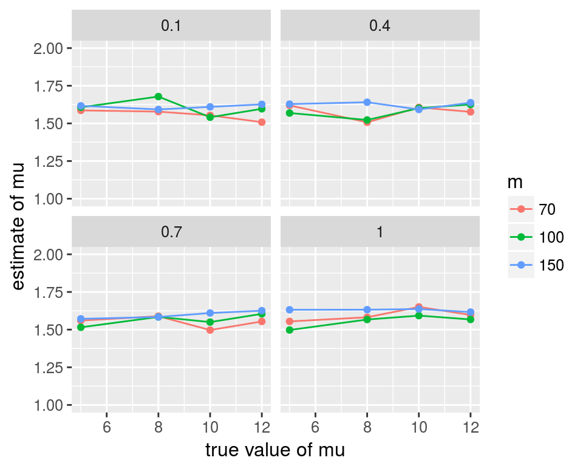

## Simulation study

**Identifiability**

\(\beta\) not good either

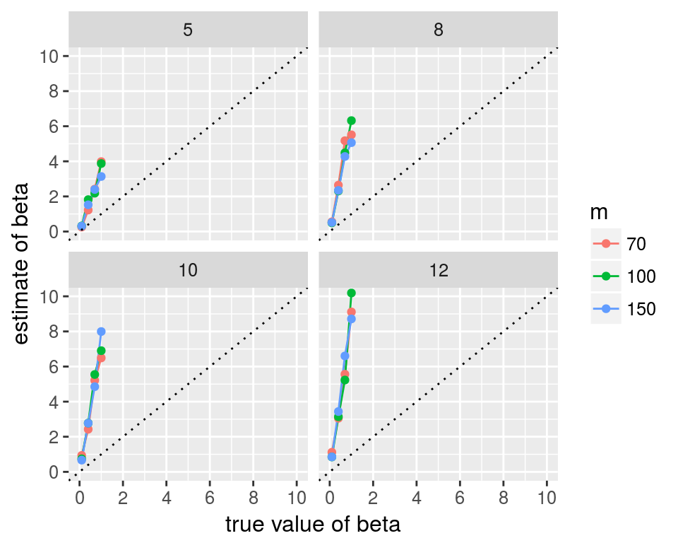

## Simulation study

**Identifiability**

What about \(\ldots \alpha=\beta\times\mu\)?

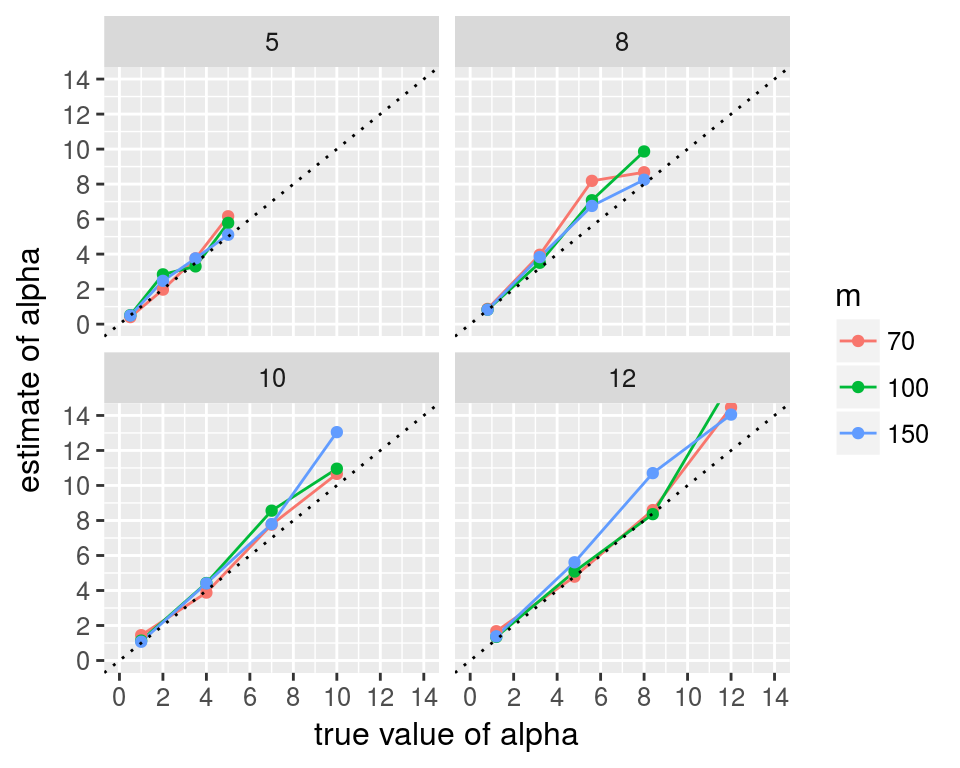

## Simulation study

**Observations**

Inverse relationship between epidemic rate \(\beta\) and parameter characterising network connectedness

- Average number new edges \(\mu\) in PA model
- Edge inclusion probability \(p\) in BRG model
  - Echoing observation by Britton and O’Neill (2002)

Identifiability

- Identifying one parameter \((\alpha)\) as good as we can get
- Interpretation: network scaled epidemic rate

## Summary

Review on network epidemics

- Statistical models assume BRG, unrealistic
- Physical models focus on dynamics, difficult to do inference

Model and inference

- PA model grows the network, SI model spreads the epidemic
- Gibbs steps for \(\beta\) and individual edges \(G_{ij}\), Metropolis steps for \(\mu\) and \(\boldsymbol{\sigma}\)

Simulation study

- Product of \(\beta\) and \(\mu\) identifiable but not individually

## Application - App Movement

Still waiting for results

Typical times taken per iteration:

- \(m=100: 0.88\text{s}\)
- \(m=200: 14\text{s}\)

Computational time \(O(m^4)\)

- # potential edges \((G_{ij})\) to update \(O(m^2)\)
- # computations involved in updating one edge \(O(m^2)\)

Data sets worth applying the model to

- \(m = 350\) and up

## Future work

Apply to App Movement data

- Sample sizes \(m\) much larger than in simulation study
- Current MCMC algorithm not scalable with \(m\)

Compare with models which use BRG

- One possible way: calculate the marginal likelihoods

Marginal MCMC methods by simulating the network

- Direct according to the preferential attachment rule
- Takes much less time than updating the edges one by one

## Bibliography

Andersson, Hakan, and Tom Britton. 2000. *Stochastic Epidemic Models and Their Statistical Analysis*. Lecture Notes in Statistics 151. Springer, New York.

Ball, Frank, D. Mollison, and G. Scalia-Tomba. 1997. “Epidemics with Two Levels of Mixing.” *Annals of Applied Probability* 7: 46–89.

Barabási, Albert-László, and Réka Albert. 1999. “Emergence of Scaling in Random Networks.” *Science* 286 (5439): 509–12.

Bezáková, Ivona, Adam Kalai, and Rahul Santhanam. 2006. “Graph Model Selction Using Maximum Likelihood.” In *Proceedings of the \(23^{rd}\) International Conference on Machine Learning, Pittsburgh, PA, 2006*. International Machine Learning Society.

Britton, Tom, and Philip D. O’Neill. 2002. “Bayesian Inference for Stochastic Epidemics in Populations with Random Social Structure.” *Scandinavian Journal of Statistics* 29 (3): 375–90.

Britton, Tom, Theodore Kypraios, and Philip D. O’Neill. 2011. “Inference for Epidemics with Three Levels of Mixing:methodology and Application to a Measles Outbreak.” *Scandinavian Journal of Statistics* 38: 578–99. doi:10.1111/j.1467-9469.2010.00726.x.

Neal, Peter, and Gareth Roberts. 2005. “A Case Study in Non-Centering for Data Augmentation: Stochastic Epidemics.” *Statistics and Computing* 15: 315–27.

Pastor-Satorras, Romualdo, Claudio Castellano, Piet Van Mieghem, and Alessandro Vespignani. 2015. “Epidemic Processes in Complex Networks.” *Reviews of Modern Physics* 87 (3): 925–79. doi:10.1103/RevModPhys.87.925.